# Fair Subsampling from Very Large Datasets

Sheila Braun

July 16, 2019

```r
options(digits = 3, scipen = 9999)
sh <- suppressMessages # it's a library, so sh!
shh <- suppressWarnings
shhh <- suppressPackageStartupMessages
sh(shh(shhh(if(!require(dataPreparation)){install.packages("dataPreparation")})))
sh(shh(shhh(if(!require(fastDummies)){install.packages("fastDummies")})))
sh(shh(shhh(if(!require(gridBase)){install.packages("gridBase")})))
#sh(shh(shhh(if(!require(ggthemr)){install.packages("ggthemr")})))
```

# An Example of Unfairness

Fake data: create a very long vector of greetings

```r
greetings = c("Ciao",
              "Nǐn hǎo",
              "Guten tag",
              "Bonjour",
              "Olá",
              "Bom dia",
              "Zdravstvuyte",
              "Shalom",
              "Gudmoning!",
              "Aloha")

set.seed(9699)
greeting <- sample(greetings,
                   size = 10000000,
                   replace = TRUE,
                   prob = c(10/25,
                            5/25,
                            1/25,
                            .5/25,
                            .5/25,
                            .5/25,
                            .5/25,
                            1/25,
                            .00001/25,
                     .09999/25))
```

## Summarize the Greetings

```r
library(ggplot2)
library(ggthemes)
(my_table <- base::table(greeting))
```

```
greeting
       Aloha      Bom dia      Bonjour         Ciao   Gudmoning!    Guten tag
       52322       262018       261873      5233884            6       523836
     Nǐn hǎo          Olá       Shalom Zdravstvuyte
     2617573       262755       523875       261858
```

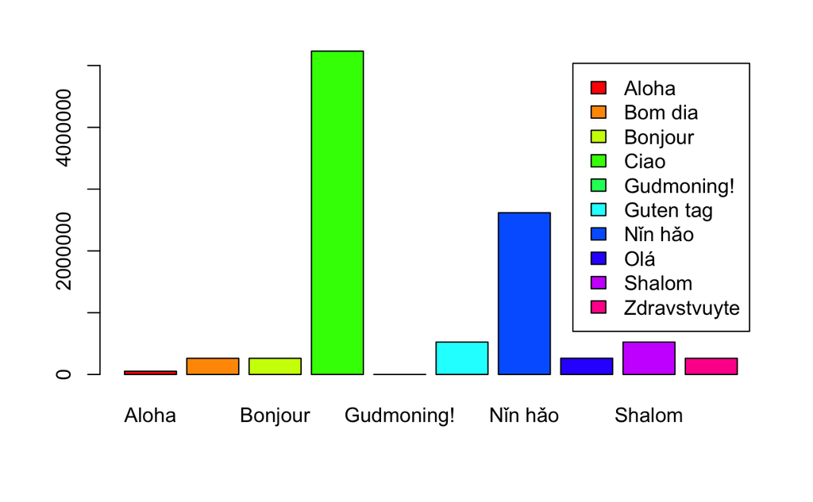

```r
barplot(my_table, col = rainbow(10), legend = TRUE)
```

## Random Samples of Greetings

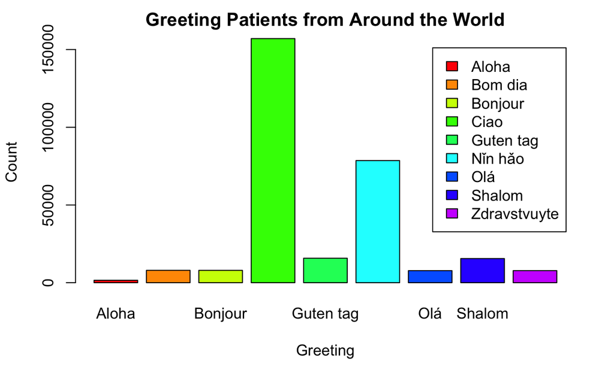

```r
plot_subsample <- function(greeting, how_many) {
  set.seed(9699)
  library(gridBase)
  barplot(table(sample(greeting, how_many)),
       main = "Greeting Patients from Around the World",
       xlab = "Greeting",
       ylab = "Count",
       col = rainbow(10),
       legend = TRUE)
}

how_many <- 30

plot_subsample(greeting, how_many * 10000)
```

# An Example of Critical Unfairness

This time the data is a list of symptoms of a virus you, the brilliant epidemiologist, have just identified. We’ll repeat the randomization to create the data and the descriptive statistics.

### Symptoms

```r
symptoms = c("Coughing",
             "Rash",
             "Sleeplessness",
             "Listlessness",
             "Loss of\nAppetite",
             "Sore Throat",
             "Bloody urine",
             "Vomiting",
             "Seizures",
             "Fever")
```

Probability of the symptoms:

```r
set.seed(960001)
symptom <- sample(symptoms,
                  size = 10000000,
                  replace = TRUE,
                  prob = c(10/25,
                           5/25,
                           1/25,
                           .5/25,
                           .5/25,
                           .5/25,
                           .5/25,
                           1/25,
                           .00001/25,
                           .09999/25))
```

## How many people died of *virus madeupticus*?

```r
table(df$died)
```

```
      No      Yes
24614492        6
```

## Can we predict fatalities?

```r
sh(shh(shhh(library(dataPreparation))))
# Encode categorical variables
# First create schema
encoding <- build_encoding(dataSet = df, cols = "auto", verbose = TRUE)
```

```
[1] "build_encoding: I will compute encoding on 3 character and factor columns."
```

```
   build_encoding [================>---------]  67% in  0s

   build_encoding [==========================] 100% in  1s
```

```
[1] "build_encoding: it took me: 1.41s to compute encoding for 3 character and factor columns."
```

```r
# Now change data sets to reflect encoding and have a look
df <- one_hot_encoder(dataSet = df, encoding = encoding, drop = TRUE, verbose = TRUE)
```

```
[1] "one_hot_encoder: I will one hot encode some columns."
[1] "one_hot_encoder: I am doing column: greeting"
[1] "one_hot_encoder: I am doing column: died"
```

```
   one_hot_encoder [================>--------]  67% in  0s
```

```
[1] "one_hot_encoder: I am doing column: symptom"
```

```
   one_hot_encoder [=========================] 100% in  4s
```

```
[1] "one_hot_encoder: It took me 7.07s to transform 3 column(s)."
```

```r
# Create train & test indices
train_index <- sample(1:nrow(df), 0.8 * nrow(df))
test_index <- setdiff(1:nrow(df), train_index)

# Create train & test sets
train <- df[train_index,]
test <- df[test_index,]
```

## Data preparation is done. Now create a model using the training set.

```r
#model <- lm(died.Yes ~ ., data = train,
#              family=binomial(link="logit"))
# summary(logitMod)

## Output:
## ERROR: FAILED TO CONVERGE
```

## What does this mean?

There is no way to predict fatalities.

Right?

Right?

## The problem:

```r
# recover df
df <- data.table::fread("df.csv")
```

```
|--------------------------------------------------|
|==================================================|
```

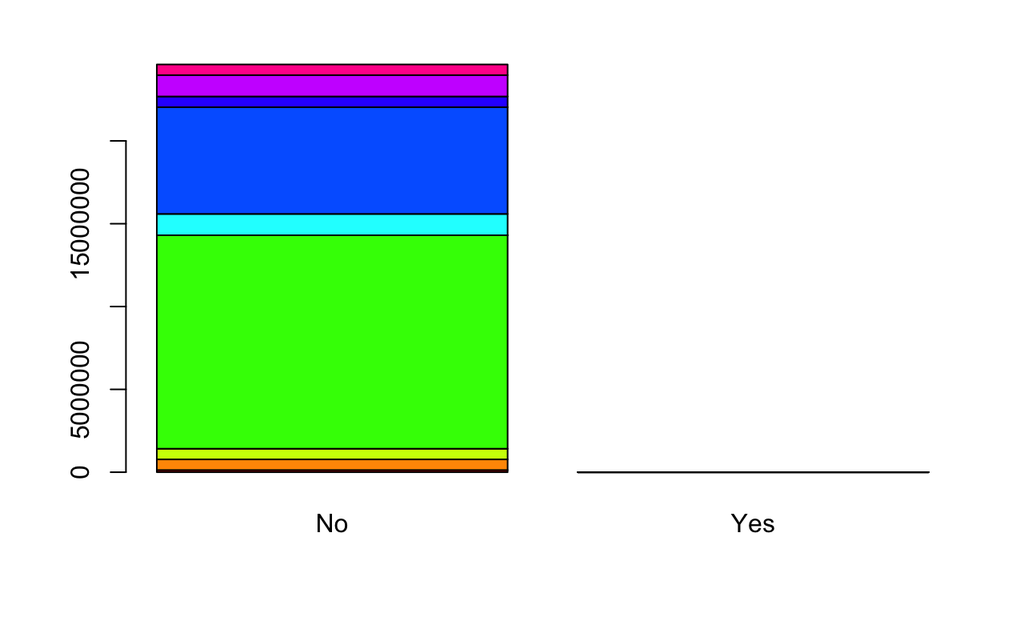

```r
barplot(table(df$greeting, df$died), col = rainbow(10))
```

```r
table(df$greeting, df$died)
```

```
                     No      Yes
  Aloha          129169        0
  Bom dia        644952        0
  Bonjour        643935        0
  Ciao         12884930        0
  Gudmoning!          0        6
  Guten tag     1288957        0
  Nǐn hǎo       6441731        0
  Olá            647181        0
  Shalom        1289007        0
  Zdravstvuyte   644630        0
```

# What can you do about it?

1. **Don’t take subsets.** Data scientists like to use all the data and there’s nothing wrong with that if you can do it.
2. **Exploratory analysis is good–and it’s good for you!** We would not have needed to go through all that work if we’d done a few simple tables at the beginning to see how variables interacted.

```r
table(df$symptom, df$died)
```

```
                        No     Yes
  Bloody urine     1006119       0
  Coughing         9485005       0
  Fever             207455       0
  Listlessness     1006002       0
  Loss of Appetite 1006559       0
  Rash             7030109       0
  Seizures              19       6
  Sleeplessness    1934166       0
  Sore Throat      1004472       0
  Vomiting         1934586       0
```

```r
table(df$symptom, df$greeting)
```

```
                     Aloha Bom dia Bonjour    Ciao Gudmoning! Guten tag Nǐn hǎo
  Bloody urine        5256   26140   26192  526985          0     52772  263247
  Coughing           49622  248470  248537 4964509          0    496844 2482153
  Fever               1084    5519    5482  108549          0     10867   54027
  Listlessness        5238   26750   26201  526285          0     52981  262944
  Loss of Appetite    5274   26333   26302  526300          0     52766  264087
  Rash               36919  184205  184128 3679183          0    368076 1841051
  Seizures               0       0       2       7          6         1       3
  Sleeplessness      10117   50759   50268 1012858          0    100861  506362
  Sore Throat         5385   26364   26104  525639          0     52476  262619
  Vomiting           10274   50412   50719 1014615          0    101313  505238

                       Olá  Shalom Zdravstvuyte
  Bloody urine       26526   52461        26540
  Coughing          249311  496917       248642
  Fever               5482   10948         5497
  Listlessness       26531   52842        26230
  Loss of Appetite   26356   52907        26234
  Rash              184859  367708       183980
  Seizures               0       3            3
  Sleeplessness      50958  101401        50582
  Sore Throat        26533   52906        26446
  Vomiting           50625  100914        50476
```

But sometimes you just can’t find anything. You have 250 variables and 10,000,000 cases, for instance. What do you do?

3. **Try Cost-sensitive Learning**. This method evaluates the cost associated with misclassifying data. Use it to decide how important it is to find absolutely all the relationships among your variables.

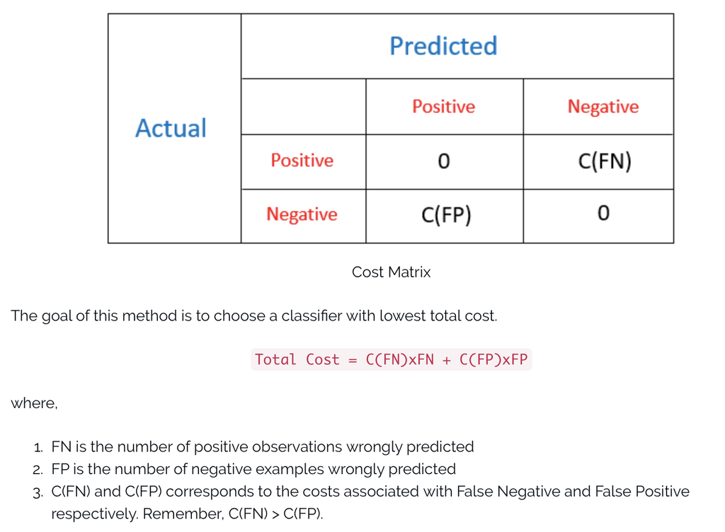

Cost-sensitive learning table

4. **Avoid random sampling**. *Random sampling* is taking a random sample of anyone from any group or subgroup in your data set. it’s what I did above. **Why this won’t work**: You might not get anybody from Vanuatu. In fact, you almost certainly won’t unless you take a hefty portion of the data set in your random sample.

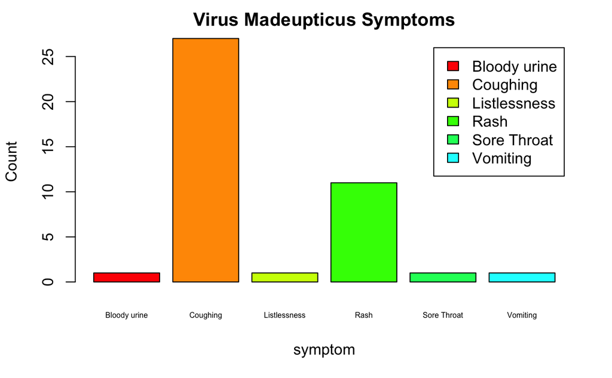

```r
plot_subsample <- function(symptom, how_many) {
  set.seed(100)
  barplot(table(sample(symptom, how_many)),
          main = "Virus Madeupticus Symptoms",
          xlab = "symptom",
          ylab = "Count",
          col=rainbow(10), legend = TRUE,
          cex.names = .50,
          beside = TRUE)
}
how_many <- 42
plot_subsample(symptom, how_many)
```

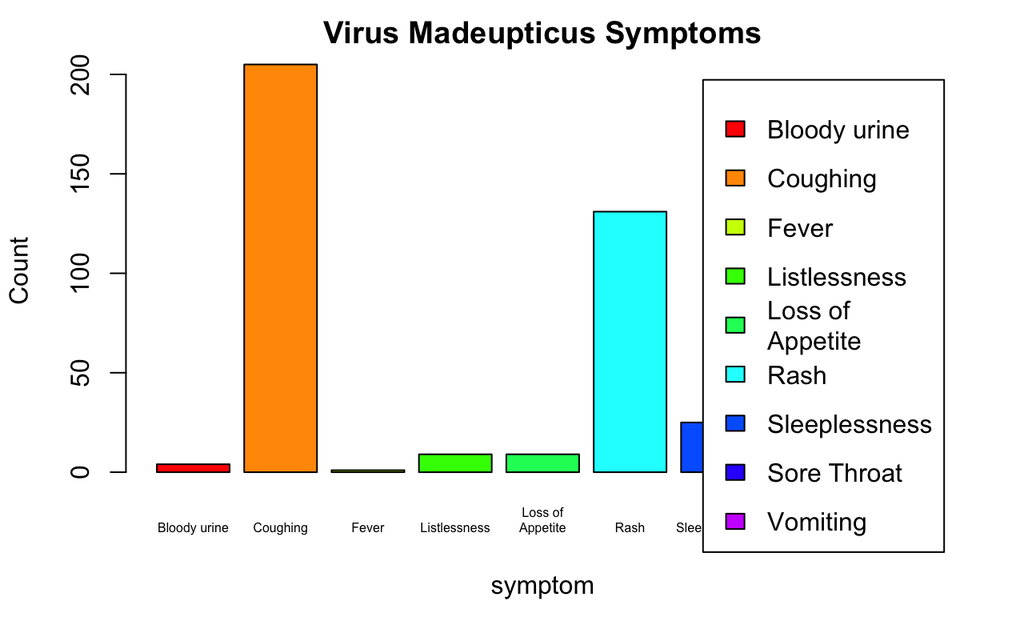

```r
plot_subsample(symptom, how_many * 10)
```

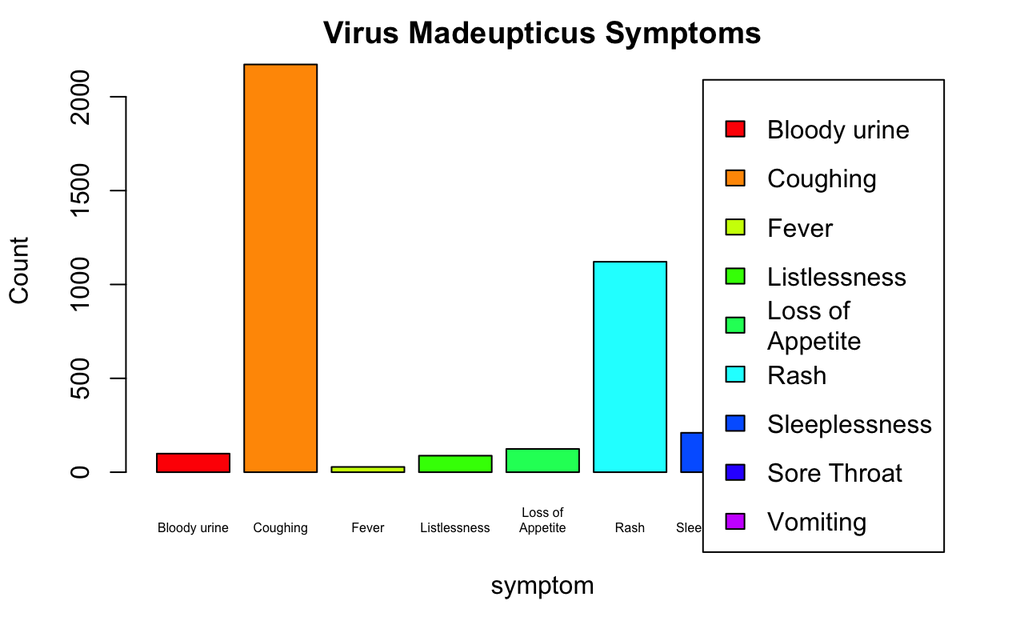

```r
plot_subsample(symptom, how_many * 100)
```

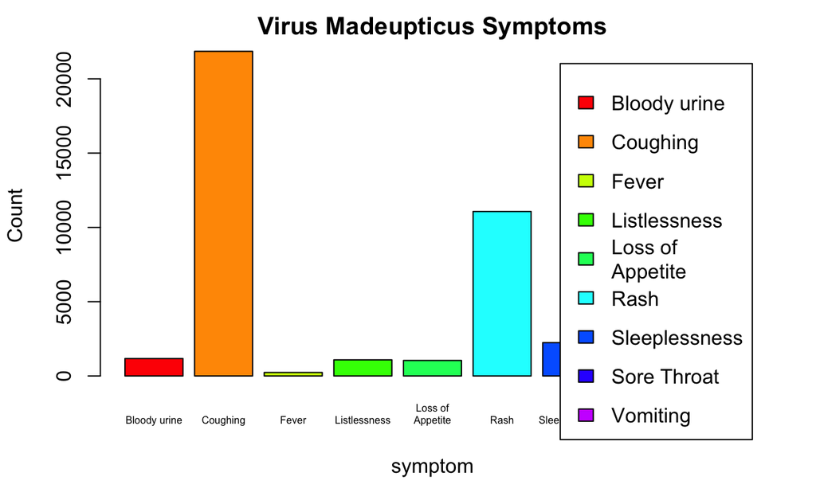

```r
plot_subsample(symptom, how_many * 1000)
```

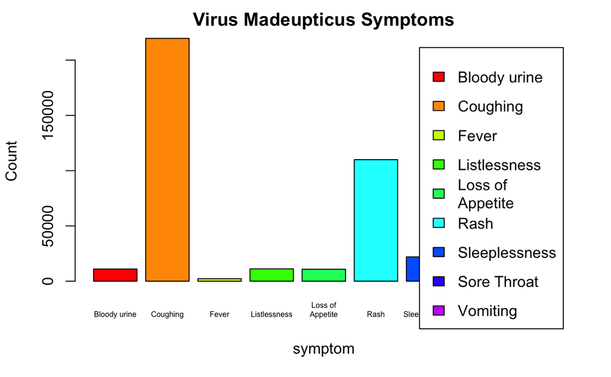

```r
plot_subsample(symptom, how_many * 10000)
```

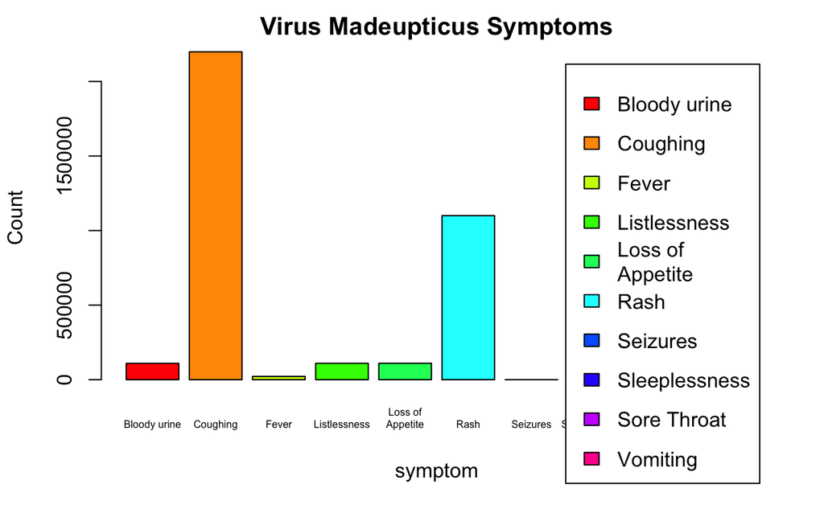

```r
plot_subsample(symptom, how_many * 100000)
```

5. **Avoid traditional stratified random sampling**: Stratified random sampling seems like a great idea because you create a subsample that takes a percentage of each group. The percentage is equal to the percentage that group represents in the entire data set. **Why this won’t work**: We’d have even fewer than 6 people from Vanuatu in the data set.

# Solution

1. Use cost-sensitive learning to establish importance
2. Use exploratory data analysis to find all the majorities and all the hidden minorities, then write your descriptive analysis code using the data dictionary to inform it (this makes it easier to include all the important variables). You’ll find shortcuts as you go along. Be thorough in this step.
3. Oversample minority groups if you must, as undersampling the majority is better. In cases like ours, however, we must oversample because the minority group is so very small.
4. Undersample the majorities. Read on to find out how.

### One way to Undersample Majority Groups: Clustering

1. Divide the majority class into a bunch of *distinct* clusters (each element of the data shows up only once in the clusters).
2. Train each of these cluster with *all* observations from minority class, oversampling the minority if that’s necessary for them to show up fairly (in our example, we would have to do this).
3. Finally, average your final predictions to get an accurate prediction.

> When to think about fairness: all the time—especially when it is *critical* that you account for all the categories in your data set.

# For more on this problem

- Class Imbalance, and Cost Sensitivity: Why Under-Sampling beats Over-Sampling: http://citeseerx.ist.psu.edu/viewdoc/download?doi=10.1.1.68.6858&rep=rep1&type=pdf
- The Imbalanced Training Sample Problem: Under or over Sampling? https://link.springer.com/chapter/10.1007/978-3-540-27868-9_88
- SMOTE-RSB *: a hybrid preprocessing approach based on oversampling and undersampling for high imbalanced data-sets using SMOTE and rough sets theory: https://link.springer.com/article/10.1007/s10115-011-0465-6
- Practical Guide to deal with Imbalanced Classification Problems in R: https://www.analyticsvidhya.com/blog/2016/03/practical-guide-deal-imbalanced-classification-problems/ <<== where I got the *cost-sensitive learning* table.
- [ovun.sample](https://rdrr.io/cran/ROSE/man/ovun.sample.html) is a package that aids in creating fair random samples.
- [ROSE](https://rdrr.io/cran/ROSE/man/ROSE.html) uses synthetic sampling, which we have not discussed here but which is another option for getting fair predictions.